# Homework1

Ezgi ORAL

18 11 2020

Reading Data:

```r
football = read_xlsx("C:/Users/Ezgi/Desktop/IE 582/AllDataHW1.xlsx")
noRows_inputData <- nrow(football)
```

## Task 1

### 1.a. Home Score(goals):

Observing the “Histogram for Home Score(goals)” and the corresponding Poisson distribution:

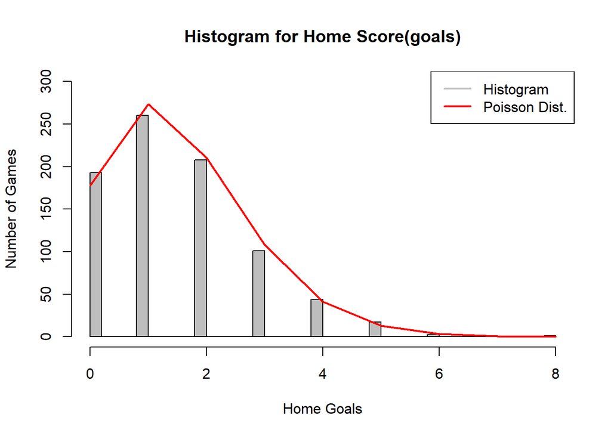

```r
HomeGoalsList <- football$FTHG
mean_HomeGoalsList <- mean(HomeGoalsList)

hist_HomeGoalsLİst = hist(HomeGoalsList, breaks = 40, main="Histogram for Home Score(goals)", xlab="Home Goals", ylab="Number of Games", lwd = 1, col = "grey", ylim=c(0, 300))
size_HomeGoalsList <- 0:(length(hist_HomeGoalsLİst)+2)
Pois_HomeGoalsList = (dpois(size_HomeGoalsList, mean_HomeGoalsList))*noRows_inputData
lines(size_HomeGoalsList, Pois_HomeGoalsList, col="red", lwd=2)
legend("topright", legend = c("Histogram", "Poisson Dist."),
       col = c("grey", "red"), lty = 1:1, lwd = 2)
```

### 1.b. Away Score(goals):

Observing the “Histogram for Away Score(goals)” and the corresponding Poisson distribution:

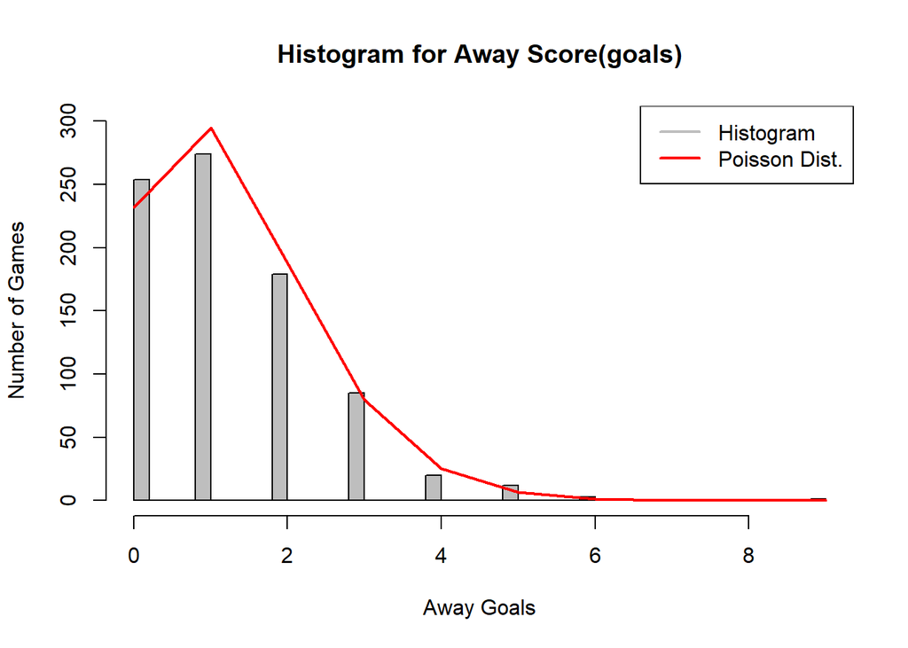

```r
AwayGoalsList <- football$FTAG
mean_AwayGoalsList <- mean(AwayGoalsList)

hist_AwayGoalsLİst = hist(AwayGoalsList, breaks = 40, main="Histogram for Away Score(goals)", xlab="Away Goals", ylab="Number of Games", lwd = 1, col = "grey", ylim=c(0, 300))
size_AwayGoalsList <- 0:(length(hist_AwayGoalsLİst)+3)
Pois_AwayGoalsList = (dpois(size_AwayGoalsList, mean_AwayGoalsList))*noRows_inputData
lines(size_AwayGoalsList, Pois_AwayGoalsList, col="red", lwd=2)
legend("topright", legend = c("Histogram", "Poisson Dist."),
       col = c("grey", "red"), lty = 1:1, lwd = 2)
```

### 1.c. Home Score(goals) – Away Score(goals):

Observing the “Histogram for Home Score(goals) - Away Score(goals)”:

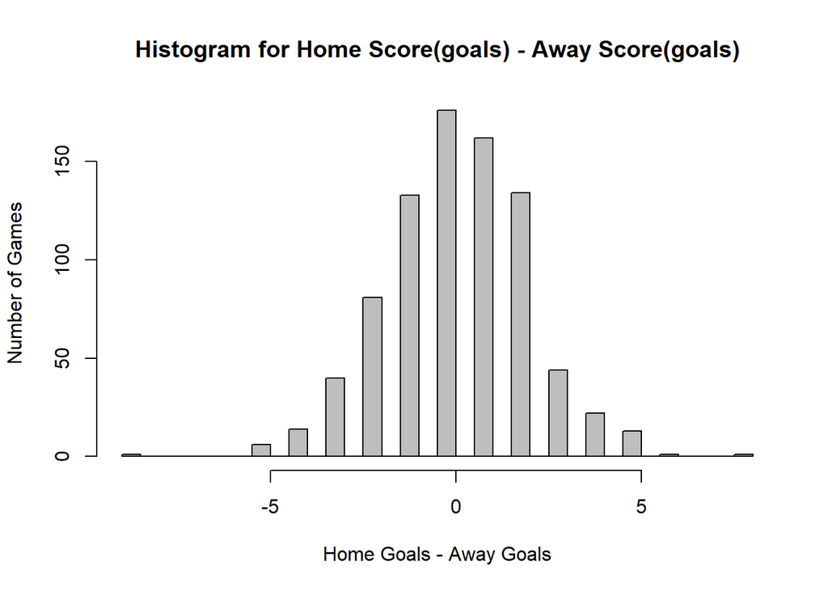

```r
SubHomeFromAway <- HomeGoalsList-AwayGoalsList

hist_SubHomeFromAway = hist(SubHomeFromAway, breaks = 40, main="Histogram for Home Score(goals) - Away Score(goals)", xlab="Home Goals - Away Goals", ylab="Number of Games", lwd = 1, col = "grey")
```

### 2. Poisson Distribution

We see that Poisson distribution fits both with home and away goals histograms. Plots above, proves that Poisson distribution fits.

## Task 2

Selected bookmakers are as follows:

Bet365 –> B365

BetAndWin –> BW

Some Bookmaker –> IW

Pinnacle –> PS

### 1. Calculating the P(home win), P(tie) and P(away win) by P(x) = 1/odd:

```r
 prob_B365H<- 1/(football$B365H)
 prob_B365D<- 1/(football$B365D)
 prob_B365A<- 1/(football$B365A)

 prob_BWH<- 1/(football$BWH)
 prob_BWD<- 1/(football$BWD)
 prob_BWA<- 1/(football$BWA)

 prob_IWH<- 1/(football$IWH)
 prob_IWD<- 1/(football$IWD)
 prob_IWA<- 1/(football$IWA)

 prob_PSH<- 1/(football$PSH)
 prob_PSD<- 1/(football$PSD)
 prob_PSA<- 1/(football$PSA)
```

### 2. Calculating probabilities by using normalization formula:

```r
 sum_365 <- (prob_B365H+ prob_B365D+ prob_B365A)
 norm_prob_B365H<- prob_B365H /(sum_365)
 norm_prob_B365D<- prob_B365D /(sum_365)
 norm_prob_B365A<- prob_B365A /(sum_365)

 sum_BW <- (prob_BWH+ prob_BWD+ prob_BWA)
 norm_prob_BWH<- prob_BWH /(sum_BW)
 norm_prob_BWD<- prob_BWD /(sum_BW)
 norm_prob_BWA<- prob_BWA /(sum_BW)

 sum_IW <- (prob_IWH+ prob_IWD+ prob_IWA)
 norm_prob_IWH<- prob_IWH /(sum_IW)
 norm_prob_IWD<- prob_IWD /(sum_IW)
 norm_prob_IWA<- prob_IWA /(sum_IW)

 sum_PS <- (prob_PSH+ prob_PSD+ prob_PSA)
 norm_prob_PSH<- prob_PSH /(sum_PS)
 norm_prob_PSD<- prob_PSD /(sum_PS)
 norm_prob_PSA<- prob_PSA /(sum_PS)
```

### 3. and 4. Plots for Draw

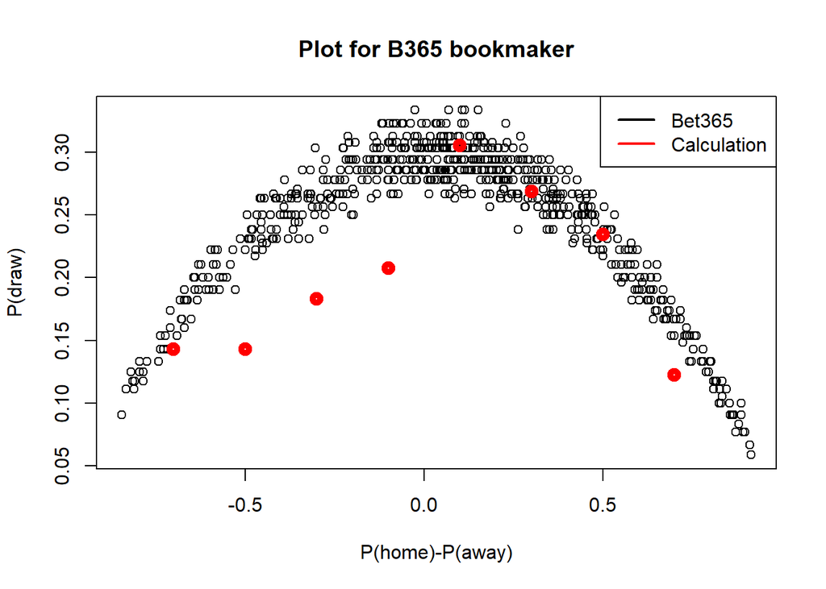

```r
sub_B365 <-  (prob_B365H - prob_B365A)
sub_BW <- (prob_BWH - prob_BWA)
sub_IW <- (prob_IWH -prob_IWA)
sub_PS <- (prob_PSH - prob_PSA)

disc_B365 <- discretize(sub_B365, "fixed", breaks = c(-1,-0.8,-0.6,-0.4,-0.2,0,0.2,0.4,0.6,0.8,1))
disc_BW <- discretize(sub_BW, "fixed", breaks = c(-1,-0.8,-0.6,-0.4,-0.2,0,0.2,0.4,0.6,0.8,1))
disc_IW <- discretize(sub_IW, "fixed", breaks = c(-1,-0.8,-0.6,-0.4,-0.2,0,0.2,0.4,0.6,0.8,1))
disc_PS <- discretize(sub_PS, "fixed", breaks = c(-1,-0.8,-0.6,-0.4,-0.2,0,0.2,0.4,0.6,0.8,1))

bool_draw<-ifelse(football$FTHG==football$FTAG,1,0)

dataForTask2_3 <- as.data.frame(cbind(bool_draw,disc_B365,disc_BW,disc_IW,disc_PS))


drawContainerB365<-vector()
totalContainerB365<-vector()
probDrawB365<-vector()

drawContainerBW<-vector()
totalContainerBW<-vector()
probDrawBW<-vector()

drawContainerIW<-vector()
totalContainerIW<-vector()
probDrawIW<-vector()

drawContainerPS<-vector()
totalContainerPS<-vector()
probDrawPS<-vector()

k=1
for (i in 1:10){

drawContainerB365[k] <- sum(filter(dataForTask2_3, disc_B365 == i)$bool_draw)
totalContainerB365[k] <- nrow(filter(dataForTask2_3, disc_B365 == i))
probDrawB365[k] <- drawContainerB365[k]/totalContainerB365[k]

drawContainerBW[k] <- sum(filter(dataForTask2_3, disc_BW == i)$bool_draw)
totalContainerBW[k] <- nrow(filter(dataForTask2_3, disc_BW == i))
probDrawBW[k] <- drawContainerBW[k]/totalContainerBW[k]

drawContainerIW[k] <- sum(filter(dataForTask2_3, disc_IW == i)$bool_draw)
totalContainerIW[k] <- nrow(filter(dataForTask2_3, disc_IW == i))
probDrawIW[k] <- drawContainerIW[k]/totalContainerIW[k]

drawContainerPS[k] <- sum(filter(dataForTask2_3, disc_PS == i)$bool_draw)
totalContainerPS[k] <- nrow(filter(dataForTask2_3, disc_PS == i))
probDrawPS[k] <- drawContainerPS[k]/totalContainerPS[k]


k=k+1
}

plot(sub_B365,prob_B365D,main="Plot for B365 bookmaker",xlab = "P(home)-P(away)", ylab = "P(draw)")
points(c(-0.9,-0.7,-0.5,-0.3,-0.1,0.1,0.3,0.5,0.7,0.9),probDrawB365, lwd=5 ,col = "red")
legend("topright", legend = c("Bet365", "Calculation"),
       col = c("black", "red"), lty = 1:1, lwd = 2)
```

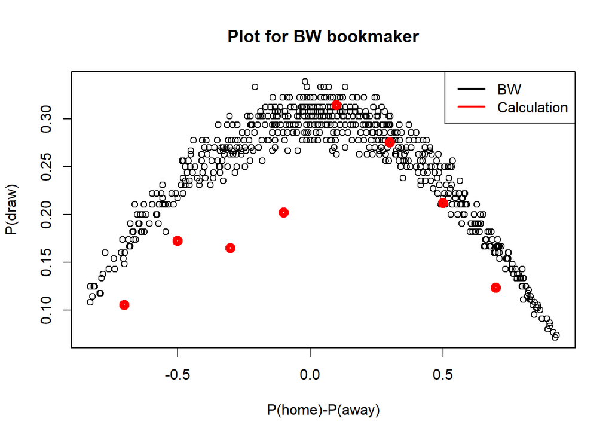

```r
plot(sub_BW,prob_BWD,main="Plot for BW bookmaker",xlab = "P(home)-P(away)", ylab = "P(draw)")
points(c(-0.9,-0.7,-0.5,-0.3,-0.1,0.1,0.3,0.5,0.7,0.9),probDrawBW, lwd=5 ,col = "red")
legend("topright", legend = c("BW", "Calculation"),
       col = c("black", "red"), lty = 1:1, lwd = 2)
```

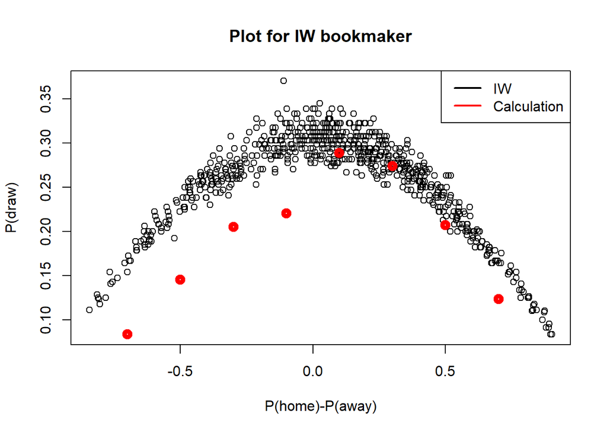

```r
plot(sub_IW,prob_IWD,main="Plot for IW bookmaker",xlab = "P(home)-P(away)", ylab = "P(draw)")
points(c(-0.9,-0.7,-0.5,-0.3,-0.1,0.1,0.3,0.5,0.7,0.9),probDrawIW, lwd=5 ,col = "red")
legend("topright", legend = c("IW", "Calculation"),
       col = c("black", "red"), lty = 1:1, lwd = 2)
```

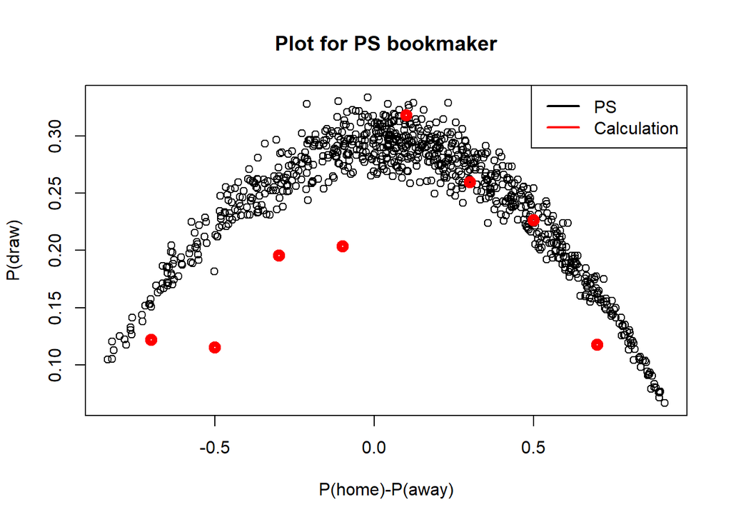

```r
plot(sub_PS,prob_PSD,main="Plot for PS bookmaker",xlab = "P(home)-P(away)", ylab = "P(draw)")
points(c(-0.9,-0.7,-0.5,-0.3,-0.1,0.1,0.3,0.5,0.7,0.9),probDrawPS, lwd=5 ,col = "red")
legend("topright", legend = c("PS", "Calculation"),
       col = c("black", "red"), lty = 1:1, lwd = 2)
```

For most cases(intervals), since the probabilities calculated from the sample(red dots) are not larger than the ones given by the bookmaker(black dots), one cannot potentially make money in the long run by betting on “Draw”. However, there are some intervals where the samples are above the trend line. Therefore, one can potentially make money within these intervals.

## Task 3

Now, we remove the matches with red cards and make “DRAW” calculations again.

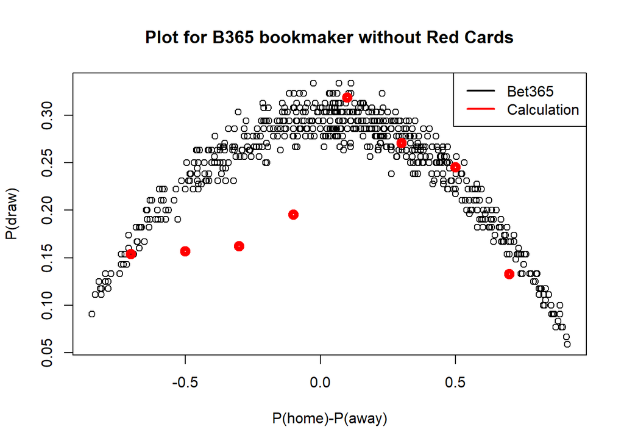

```r
football_bezCzer = filter(football, HR == 0 & AR == 0)
noRows_alteredInputData <- nrow(football_bezCzer)

prob_B365HbezCzer <- 1/(football_bezCzer$B365H)
prob_B365DbezCzer <- 1/(football_bezCzer $B365D)
prob_B365AbezCzer <- 1/(football_bezCzer $B365A)

prob_BWHbezCzer <- 1/(football_bezCzer$BWH)
prob_BWDbezCzer <- 1/(football_bezCzer$BWD)
prob_BWAbezCzer <- 1/(football_bezCzer$BWA)

prob_IWHbezCzer <- 1/(football_bezCzer$IWH)
prob_IWDbezCzer <- 1/(football_bezCzer$IWD)
prob_IWAbezCzer <- 1/(football_bezCzer$IWA)

prob_PSHbezCzer <- 1/(football_bezCzer $PSH)
prob_PSDbezCzer <- 1/(football_bezCzer $PSD)
prob_PSAbezCzer <- 1/(football_bezCzer $PSA)


sub_B365bezCzer <-  (prob_B365HbezCzer  - prob_B365AbezCzer )
sub_BWbezCzer  <- (prob_BWHbezCzer  - prob_BWAbezCzer )
sub_IWbezCzer  <- (prob_IWHbezCzer  -prob_IWAbezCzer )
sub_PSbezCzer  <- (prob_PSHbezCzer  - prob_PSAbezCzer )



disc_B365bezCzer  <- discretize(sub_B365bezCzer , "fixed", breaks = c(-1,-0.8,-0.6,-0.4,-0.2,0,0.2,0.4,0.6,0.8,1))
disc_BWbezCzer  <- discretize(sub_BWbezCzer , "fixed", breaks = c(-1,-0.8,-0.6,-0.4,-0.2,0,0.2,0.4,0.6,0.8,1))
disc_IWbezCzer  <- discretize(sub_IWbezCzer , "fixed", breaks = c(-1,-0.8,-0.6,-0.4,-0.2,0,0.2,0.4,0.6,0.8,1))
disc_PSbezCzer  <- discretize(sub_PSbezCzer , "fixed", breaks = c(-1,-0.8,-0.6,-0.4,-0.2,0,0.2,0.4,0.6,0.8,1))

bool_drawbezCzer <-ifelse(football_bezCzer $FTHG==football_bezCzer$FTAG,1,0)

dataForTask3bezCzer  <- as.data.frame(cbind(bool_drawbezCzer ,disc_B365bezCzer ,disc_BWbezCzer ,disc_IWbezCzer ,disc_PSbezCzer ))


drawContainerB365bezCzer <-vector()
totalContainerB365bezCzer <-vector()
probDrawB365bezCzer <-vector()

drawContainerBWbezCzer <-vector()
totalContainerBWbezCzer <-vector()
probDrawBWbezCzer <-vector()

drawContainerIWbezCzer <-vector()
totalContainerIWbezCzer <-vector()
probDrawIWbezCzer <-vector()

drawContainerPSbezCzer <-vector()
totalContainerPSbezCzer <-vector()
probDrawPSbezCzer <-vector()

m=1
for (i in 1:10){

        drawContainerB365bezCzer [m] <- sum(filter(dataForTask3bezCzer , disc_B365bezCzer  == i)$bool_drawbezCzer )
        totalContainerB365bezCzer [m] <- nrow(filter(dataForTask3bezCzer , disc_B365bezCzer  == i))
        probDrawB365bezCzer [m] <- drawContainerB365bezCzer [m]/totalContainerB365bezCzer [m]

        drawContainerBWbezCzer [m] <- sum(filter(dataForTask3bezCzer , disc_BWbezCzer  == i)$bool_drawbezCzer )
        totalContainerBWbezCzer [m] <- nrow(filter(dataForTask3bezCzer , disc_BWbezCzer  == i))
        probDrawBWbezCzer [m] <- drawContainerBWbezCzer[m]/totalContainerBWbezCzer[m]

        drawContainerIWbezCzer [m] <- sum(filter(dataForTask3bezCzer , disc_IWbezCzer  == i)$bool_drawbezCzer )
        totalContainerIWbezCzer [m] <- nrow(filter(dataForTask3bezCzer , disc_IWbezCzer  == i))
        probDrawIWbezCzer [m] <- drawContainerIWbezCzer [m]/totalContainerIWbezCzer [m]

        drawContainerPSbezCzer [m] <- sum(filter(dataForTask3bezCzer , disc_PSbezCzer  == i)$bool_drawbezCzer )
        totalContainerPSbezCzer [m] <- nrow(filter(dataForTask3bezCzer , disc_PSbezCzer  == i))
        probDrawPSbezCzer [m] <- drawContainerPSbezCzer [m]/totalContainerPSbezCzer [m]


        m=m+1
}

plot(sub_B365bezCzer ,prob_B365DbezCzer ,main="Plot for B365 bookmaker without Red Cards",xlab = "P(home)-P(away)", ylab = "P(draw)")
points(c(-0.9,-0.7,-0.5,-0.3,-0.1,0.1,0.3,0.5,0.7,0.9),probDrawB365bezCzer , lwd=5 ,col = "red")
legend("topright", legend = c("Bet365", "Calculation"),
       col = c("black", "red"), lty = 1:1, lwd = 2)
```

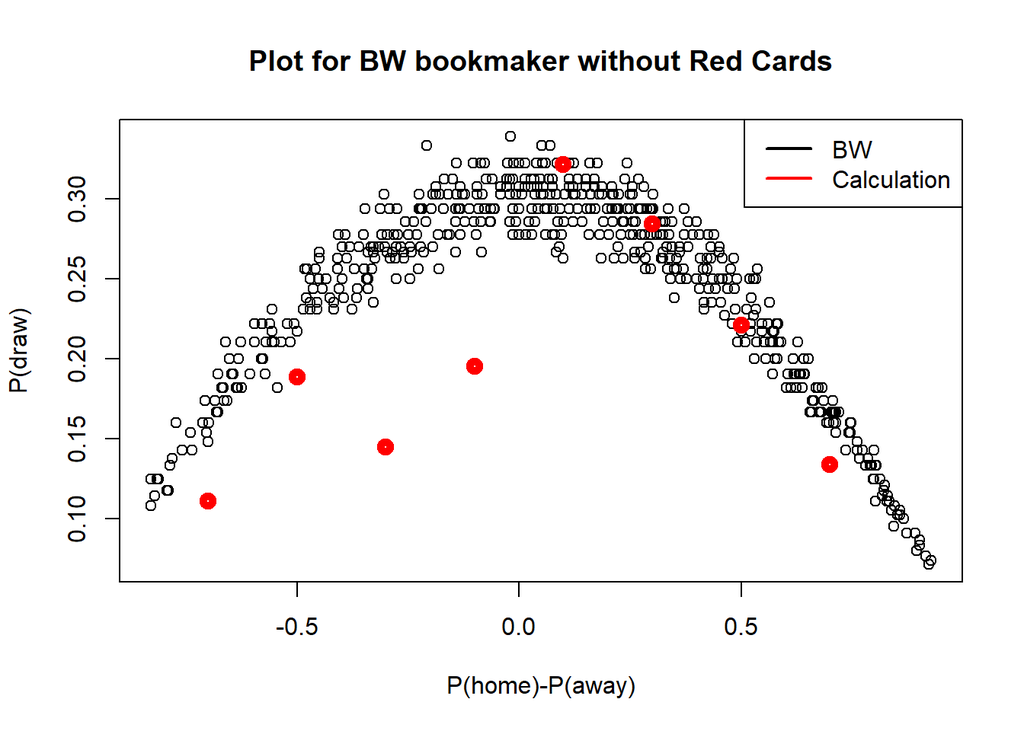

```r
plot(sub_BWbezCzer ,prob_BWDbezCzer ,main="Plot for BW bookmaker without Red Cards",xlab = "P(home)-P(away)", ylab = "P(draw)")
points(c(-0.9,-0.7,-0.5,-0.3,-0.1,0.1,0.3,0.5,0.7,0.9),probDrawBWbezCzer , lwd=5 ,col = "red")
legend("topright", legend = c("BW", "Calculation"),
       col = c("black", "red"), lty = 1:1, lwd = 2)
```

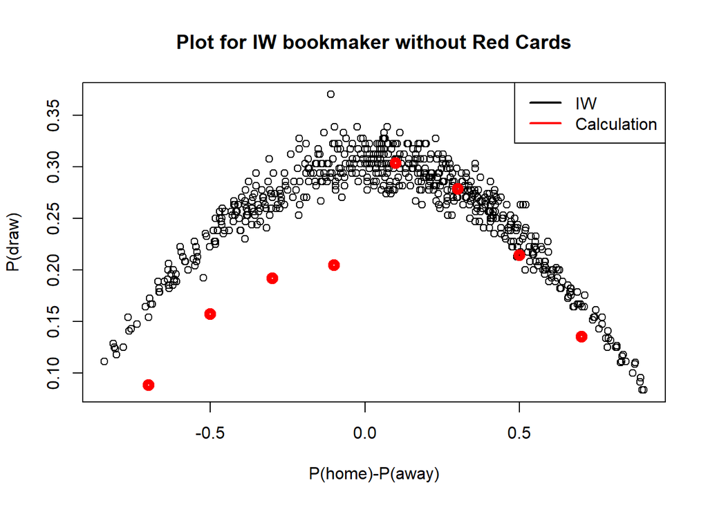

```r
plot(sub_IWbezCzer ,prob_IWDbezCzer ,main="Plot for IW bookmaker without Red Cards",xlab = "P(home)-P(away)", ylab = "P(draw)")
points(c(-0.9,-0.7,-0.5,-0.3,-0.1,0.1,0.3,0.5,0.7,0.9),probDrawIWbezCzer , lwd=5 ,col = "red")
legend("topright", legend = c("IW", "Calculation"),
       col = c("black", "red"), lty = 1:1, lwd = 2)
```

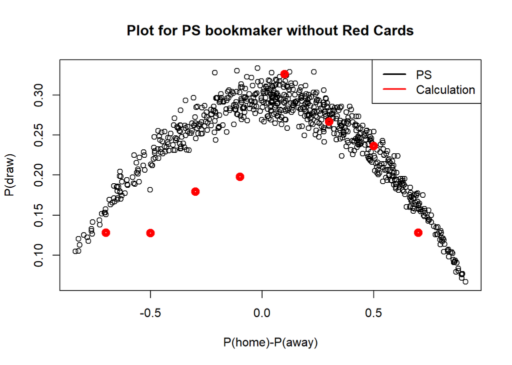

```r
plot(sub_PSbezCzer ,prob_PSDbezCzer ,main="Plot for PS bookmaker without Red Cards",xlab = "P(home)-P(away)", ylab = "P(draw)")
points(c(-0.9,-0.7,-0.5,-0.3,-0.1,0.1,0.3,0.5,0.7,0.9),probDrawPSbezCzer , lwd=5 ,col = "red")
legend("topright", legend = c("PS", "Calculation"),
       col = c("black", "red"), lty = 1:1, lwd = 2)
```

When we compare these results with Task 2, although there are some slight changes, we do not observe any significant change. Therefore, we can say that red card bookings does not effect the probability calculations and the odds significantly.